# Lecture 4: Advanced Visualization

## Visualizing the Diving Dataset

We introduced ggplot2 in Lecture 2 and used it again in Lecture 3 when combining raw data with summarized layers. Here we will keep building on that same workflow, using the diving dataset to add facets, boxplots, violin plots, barplots, and statistical summary layers.

Download diving.csv and save it to your `data` folder.

```r
library(tidyverse)
diving <- read_csv("data/diving.csv")
```

### A Quick Recap

We have already been writing ggplot code directly in earlier lectures. Here, we will start by saving the base plot to an object so that we can keep adding layers to it.

```r
diving_hist <- ggplot(data = diving)
```

Recall that aesthetics map variables to visual properties of the plot. Examples include:

- `x`: the variable that will be on the x-axis
- `y`: the variable that will be on the y-axis
- `color`: the variable that categorizes data by color
- `fill`: the variable that controls filled regions
- `shape`: the variable that categorizes data by shape

You can define the `aes()` in the `ggplot()` call, which will then be used for later layers, or you can define the `aes()` inside a specific `geom()` when it only applies there. Geometric objects, or `geoms`, determine what gets drawn. We have already used `geom_histogram()`, `geom_point()`, and `geom_line()`. In this lecture, we will add a few more:

- `geom_boxplot()`: creates a boxplot
- `geom_violin()`: creates a violin plot
- `geom_bar()`: creates a bar plot

### Putting it All Together

Let’s make a histogram of judges’ scores.

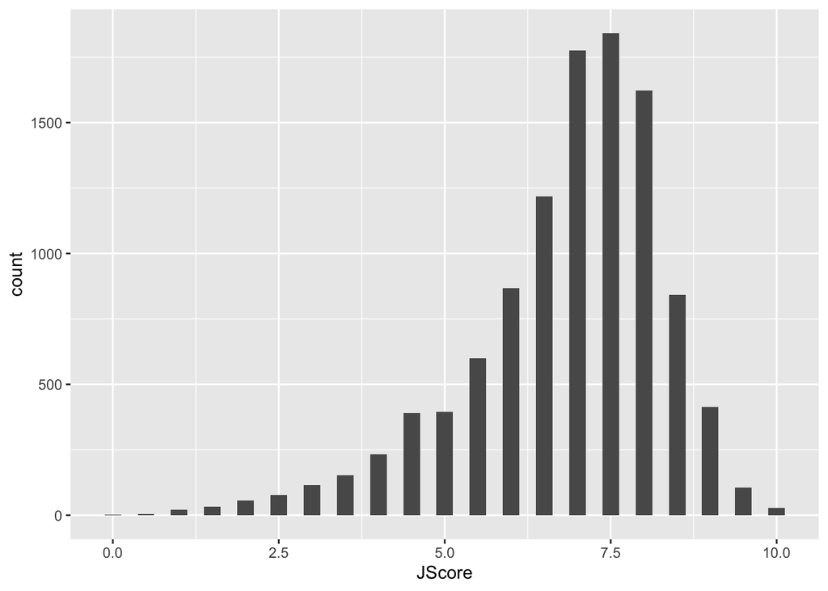

```r
diving_hist <-
  diving_hist +
  geom_histogram(aes(x = JScore), binwidth = 0.25)
diving_hist
```

In the code above, we first overwrote `diving_hist` so that it is now a histogram of judges’ scores where each bin has width 0.25. In the second line, we asked R to display this object. For ggplot code, place the `+` at the end of a line, just like the pipe `%>%`.

Notice that the label for the x-axis is JScore, which is the column name from the tbl. We can change the label by *adding* a layer.

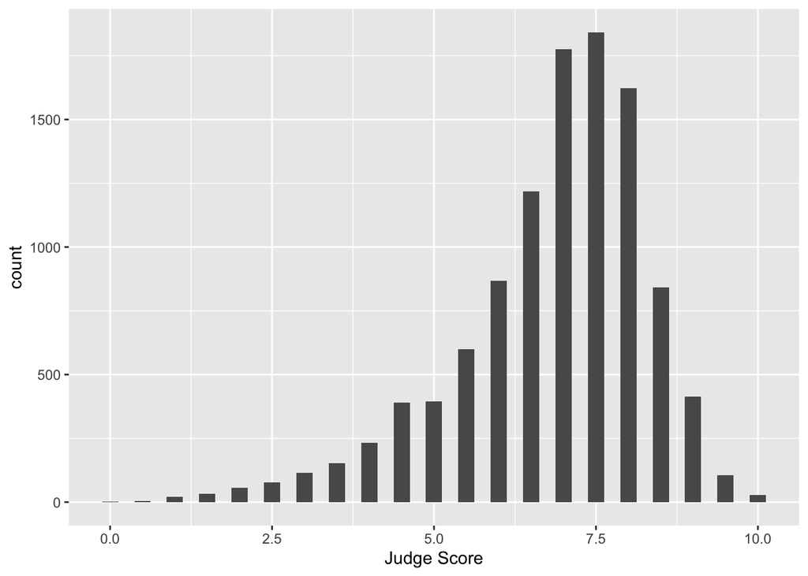

```r
diving_hist <-
  diving_hist +
  labs(x = "Judge Score")
diving_hist
```

### Facets

What if we want to separate the judges’ scores by country? We can use *facets*. Facets allow you to separate graphs by category. We do not need to redo our code for the histogram; we only need to add a *facet* layer to our graph `diving_hist`. The first argument of `facet_wrap()` is the column of our dataset that contains the category information. The second argument of `facet_wrap()` specifies the number of rows in which to display the graphs.

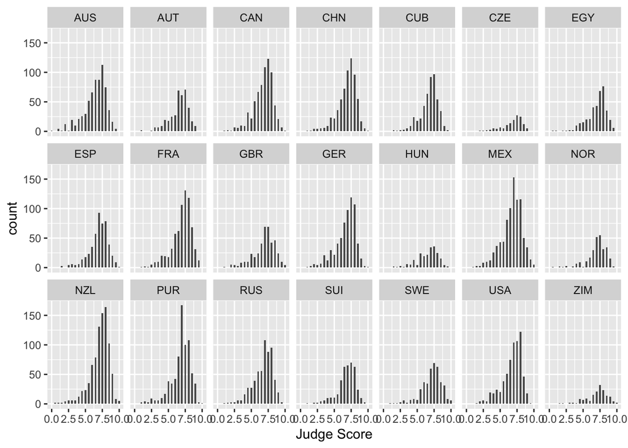

```r
diving_hist <-
  diving_hist +
  facet_wrap("JCountry", nrow = 3)
diving_hist
```

To get a sense of whether a particular country’s judges are biased, it would be useful to add a reference line at the median score over all judges and countries to each facet. So, we must first calculate the overall median score, which we can do using the `reframe()` function. Then, we can display this median on our plots with `geom_vline()`, which adds a vertical line. We can also pass in a custom color argument to this line so that it will easily stand out from the rest of our values. This website provides a look at all the built-in color arguments in R: [R colors](https://sites.stat.columbia.edu/tzheng/files/Rcolor.pdf)

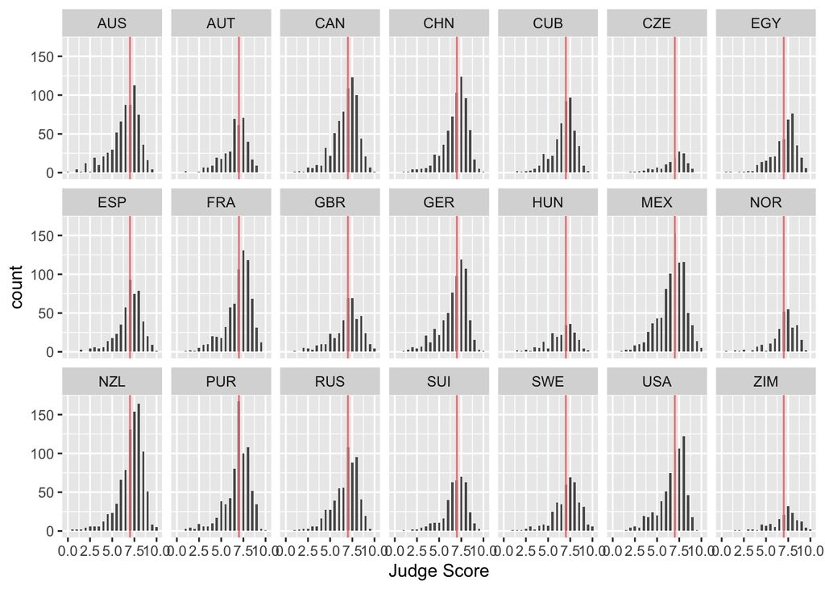

```r
median_score <- diving %>%
  reframe(med = median(JScore)) %>%
  pull(med)
diving_hist <-
  diving_hist +
  geom_vline(xintercept = median_score, color = "lightcoral")
diving_hist
```

Note that when calculating our `median_score`, the `reframe` function returns a tbl rather than a single value. To “pull” out the single median value from our tbl, we use the `pull` function.

### Boxplots and violin plots

Boxplots are also an important visualization tool. We now create boxplots of the judges’ scores, separated by diving round. We can also color our boxplots according to the `Round` variable by including the `fill` argument within the `aes()` function. Note that if we included the `fill` argument outside of the `aes()` function, we would only be able to color all boxplots the same color (by putting `fill` inside of the aesthetic, we are able to “map” the variable `Round` to the fill color of the plot based on the values of `Round`).

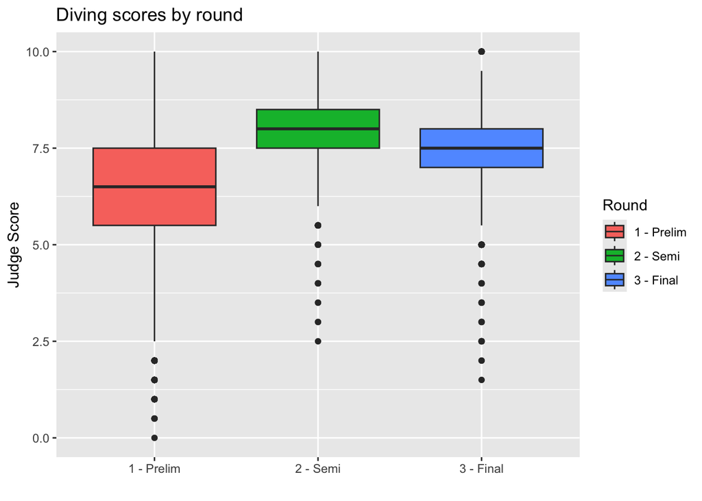

```r
diving_box <- ggplot(data = diving) +
  geom_boxplot(aes(x = Round, y = JScore, fill = Round)) +
  labs(title = "Diving scores by round", x = "", y = "Judge Score", fill = "Round")
diving_box
```

We can also remove the unnecessary x-axis ticks and labels as the legend on the right is sufficient. We do so using the `theme` layer:

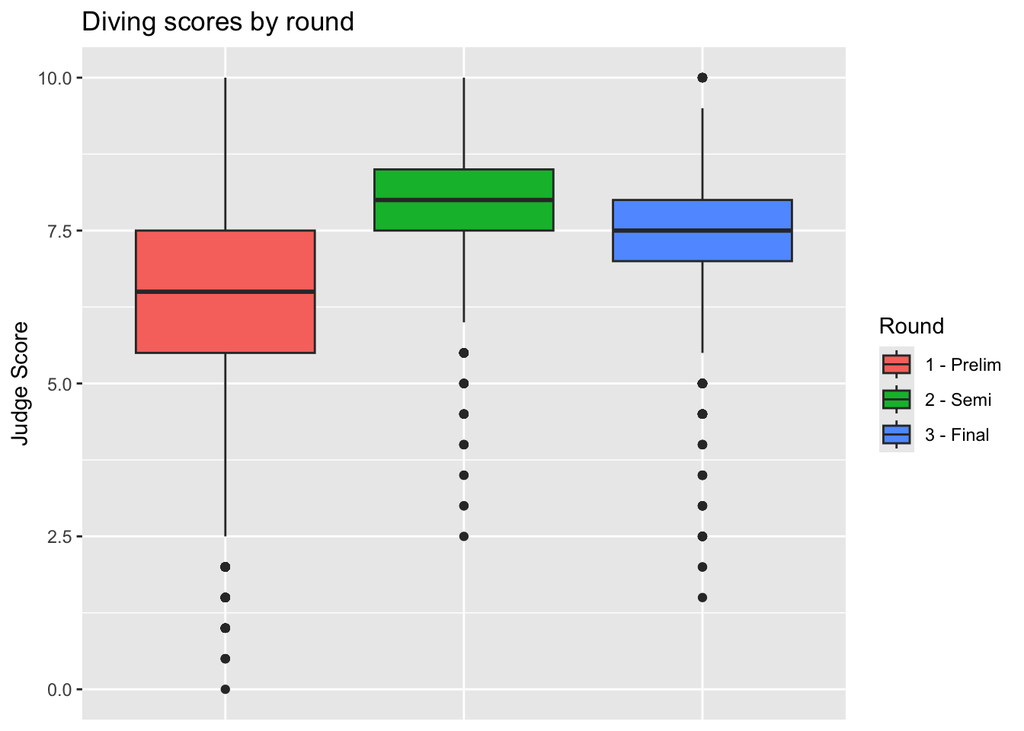

```r
diving_box <- diving_box +
  theme(axis.title.x = element_blank(), axis.text.x = element_blank(), axis.ticks.x = element_blank())
diving_box
```

We can also plot this data as violin plots, which take the same arguments as `geom_boxplot()` but use `geom_violin()` instead. We can also change the “look” of our plots by setting the theme. `theme_minimal()` is frequently used for a much cleaner look.

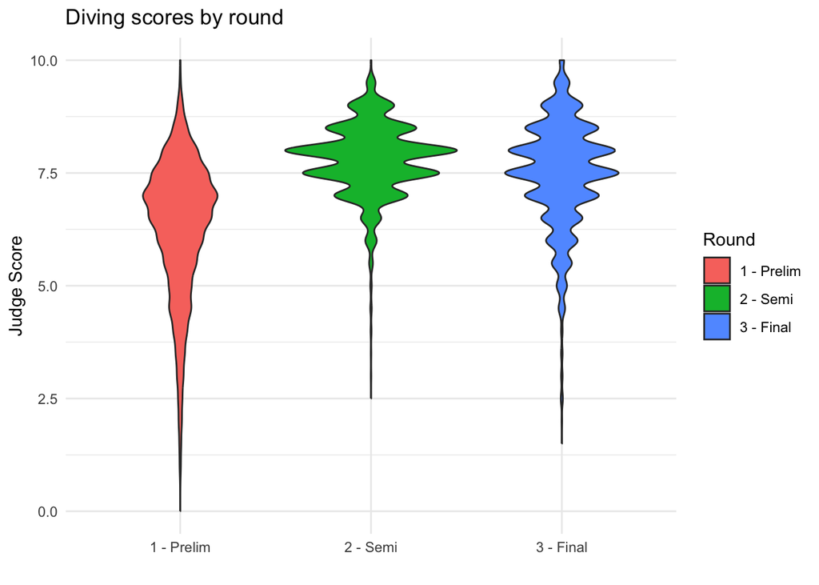

```r
diving_violin <- ggplot(data = diving) +
  geom_violin(aes(x = Round, y = JScore, fill = Round)) +
  labs(title = "Diving scores by round", x = "", y = "Judge Score", fill = "Round") +
  theme_minimal()

diving_violin
```

We can see that the boxplots provide more information about statistical features, such as the median and quartiles, but the violin plots provide a better sense of how the data is distributed. We can see the effect of smaller rounds having more binned scores, whereas they are spread much more evenly in the first round.

### Barplots

We can also create barplots using `geom_bar`. By mapping `fill=JCountry` inside our `aes()`, we can map each bar’s color to the country for that judge.

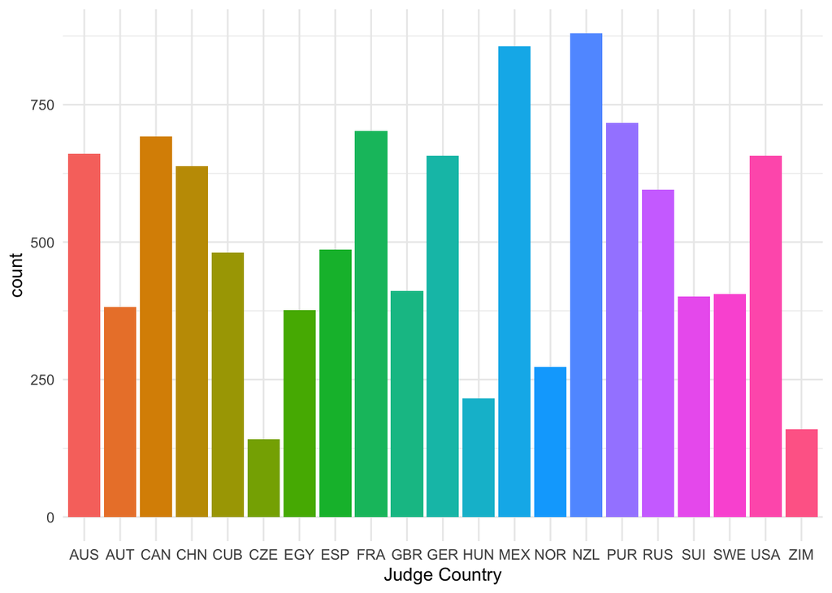

```r
bar <- ggplot(data = diving) +
  geom_bar(aes(x = JCountry, fill = JCountry)) +
  labs(x = "Judge Country") +
  theme_minimal() +
  theme(legend.position = "none")
bar
```

### Scatterplots

Now let’s turn back to scatterplots, which were introduced in Lecture 2. We plot judges’ score versus rank of the diver. As we expect, divers with better (lower-numbered) ranks tend to receive higher scores.

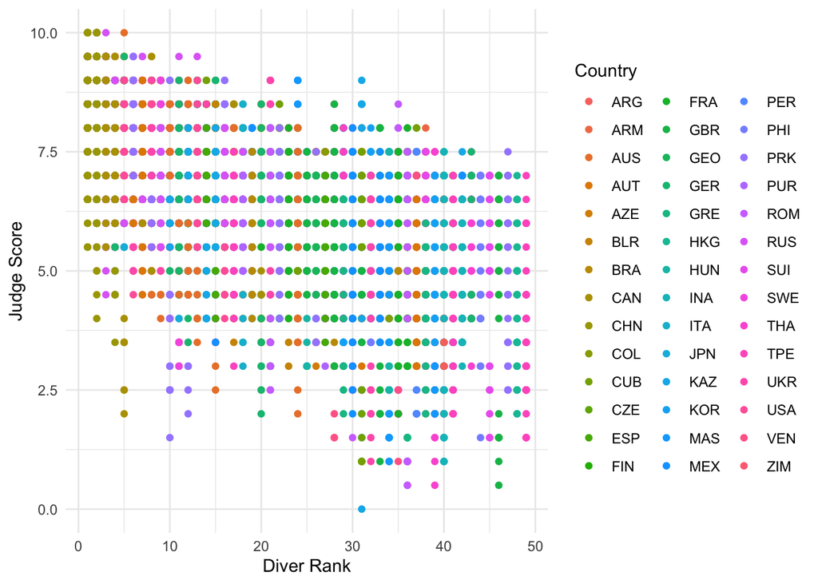

```r
scatter_raw = ggplot(data = diving) +
  geom_point(aes(x = Rank, y = JScore, color = Country)) +
  labs(x = "Diver Rank", y = "Judge Score") +
  theme_minimal()

scatter_raw
```

We can see that this plot is a little messy and hard to interpret, which may commonly happen with scatterplots when multiple rows correspond to the same thing, such as a diver. We can improve on this visual by grouping per diver and using `reframe()` to calculate the mean of the judge scores, ranks, and difficulties for each diver. We also want to save the country for visualizations, so we use the `first()` command within `reframe()`.

```r
diving_grouped <- diving %>%
  group_by(Diver) %>%
  reframe(JScore_mean = mean(JScore),
          Rank_mean = mean(Rank),
          Difficulty_mean = mean(Difficulty),
          Country = first(Country))

head(diving_grouped)
```

```
## # A tibble: 6 × 5
##   Diver              JScore_mean Rank_mean Difficulty_mean Country
##   <chr>                    <dbl>     <dbl>           <dbl> <chr>
## 1 ABALLI Jesus-Iory         6.61      22              3.08 CUB
## 2 AHRENS Stefan             7.29      10.6            2.74 GER
## 3 AKHMETBEKOV Damir         4.32      41              2.95 KAZ
## 4 ALCALA Maria-Jose         5.53      30              2.84 MEX
## 5 ALEKSEEVA Svetlana        6.87      16              2.37 BLR
## 6 ALLY Tony                 6.92      11.3            2.79 GBR
```

This will allow us to plot a single point per diver, which will make the plot much easier to interpret.

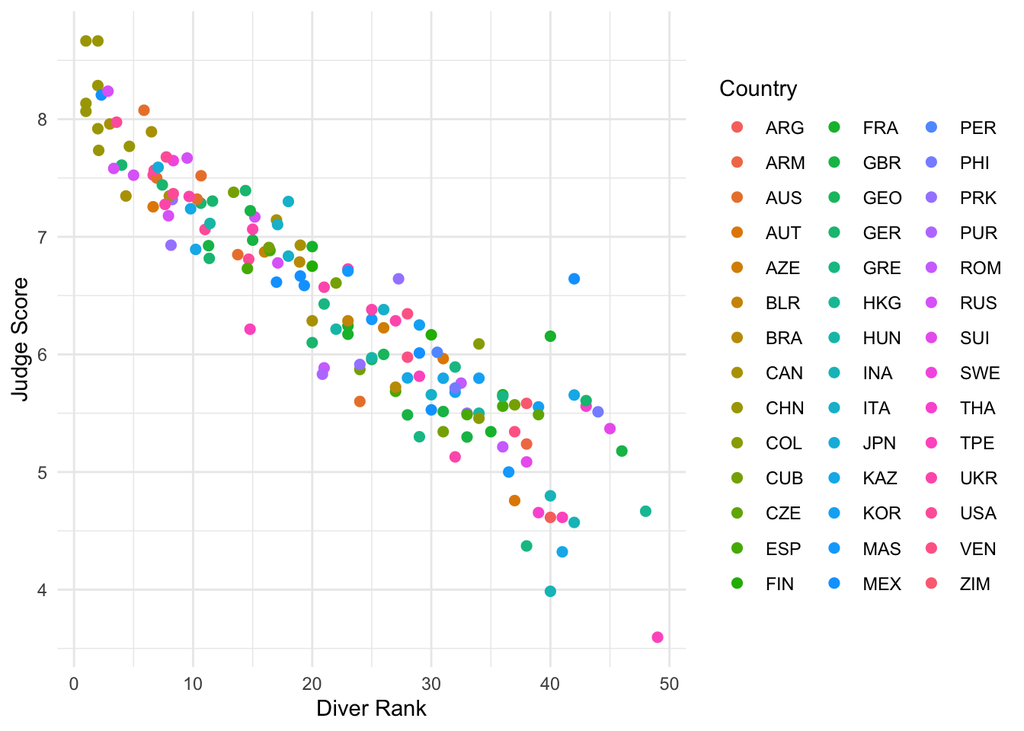

```r
scatter = ggplot(data = diving_grouped) +
  geom_point(aes(x = Rank_mean, y = JScore_mean, color = Country), size = 2) +
  labs(x = "Diver Rank", y = "Judge Score") +
  theme_minimal()

scatter
```

We can see here the much clearer negative relationship between judge score and diver rank.

### Lines

We can also add an `abline` to our scatterplot–that is, a line where we specify the y-intercept (`intercept`) and the slope (`slope`):

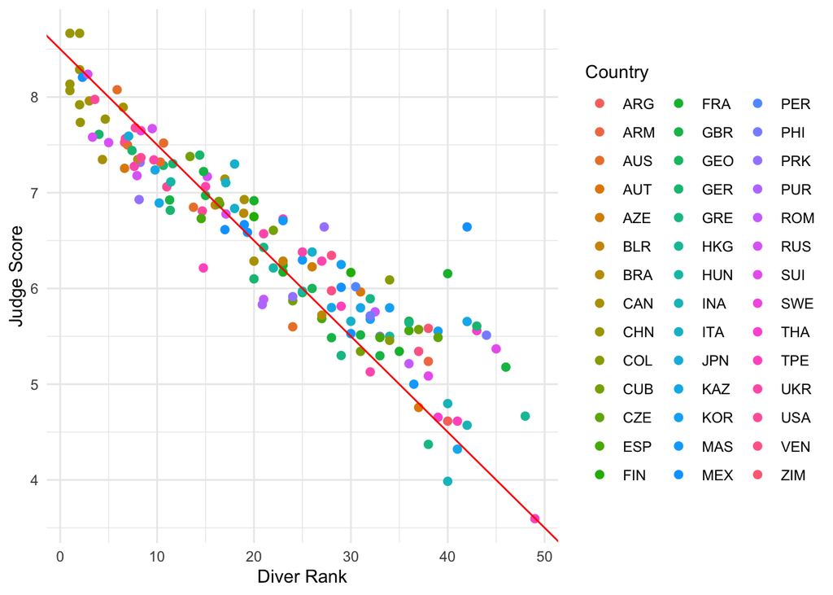

```r
scatter <- scatter +
  geom_abline(intercept = 8.5, slope = -0.1, color = "red")
scatter
```

*Note*: `geom_abline` is different from `geom_line`: `geom_line` “connects the dots” between your data and so doesn’t have to be a straight line, whereas `geom_abline` draws a straight line with the specified slope and y-intercept. A common usage is to add a visual reference line to a scatterplot.

Other `geom` for lines are:

- `geom_vline`: to add a vertical line to a plot
- `geom_hline`: to add a horizontal line to a plot

### Stats

We can also specify a layer using `stat_`, which stands for statistical transformation. This is useful if we want to plot a summary statistic of our data, such as a mean or median. By using a `stat_` layer, we do not have to compute this summary statistic beforehand–`ggplot` will compute the summary statistic for us and then plot the result.

For example, suppose we want to plot the means of each judge’s score and provide error bars of one standard error on either side of the mean. We could use `reframe` and `group_by` to find the mean and standard errors for each judge, *or* we could just use a `stat_` layer!

The layer `stat_summary()` computes and then plots a user-specified summary statistic. We choose the option `mean_se` to calculate the means and standard errors of the scores of each judge.

As always, we set up the plot by calling `ggplot`, specifying `data = diving` and then providing the `aes`. In this case, we want the judge on the `x`-axis and their scores on the `y`-axis. We then add our `stat_summary` layer.

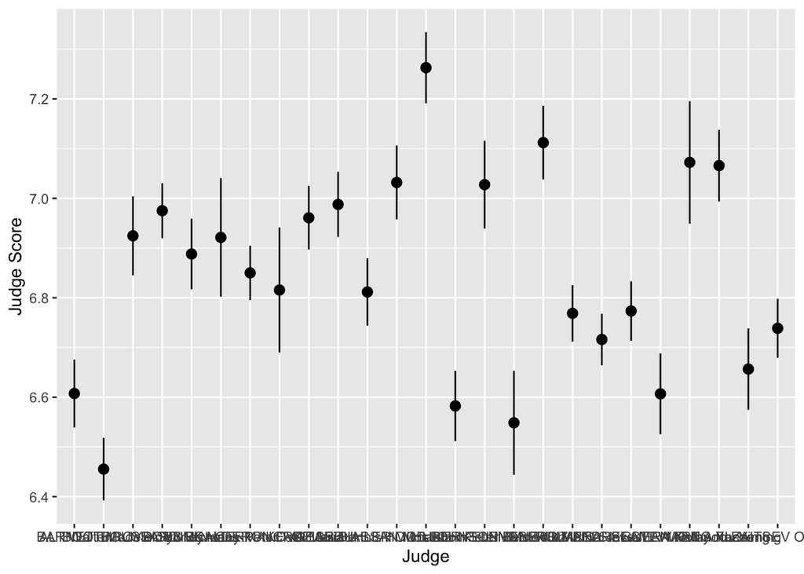

```r
judges <- ggplot(data = diving, aes(x = Judge, y = JScore)) +
  stat_summary(fun.data = mean_se) +
  labs(y = "Judge Score")
judges
```

We can see that the judges’ names are bunched together… we can make them much more readable by rotating the x-axis labels by 45 degrees using the `theme` layer:

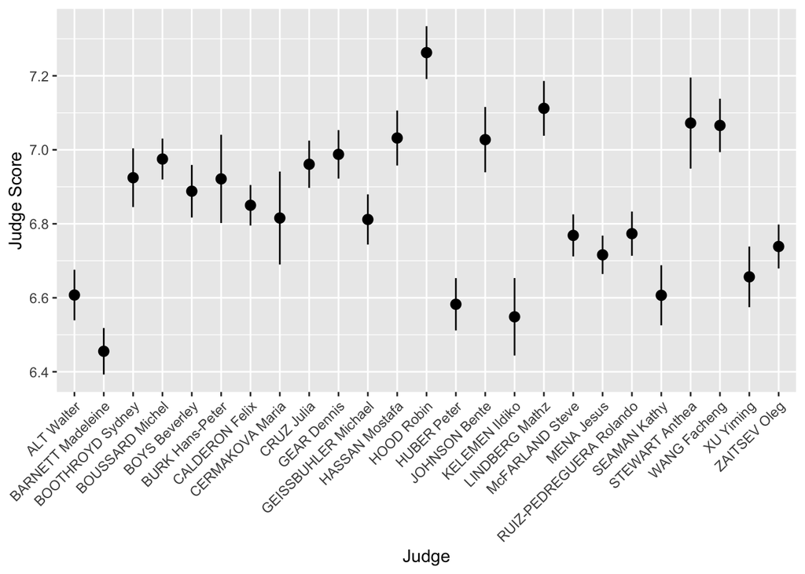

```r
judges_rotate <- judges +
  theme(axis.text.x = element_text(angle = 45, hjust = 1))
judges_rotate
```

We can also completely flip the coordinates to make a horizontal plot!

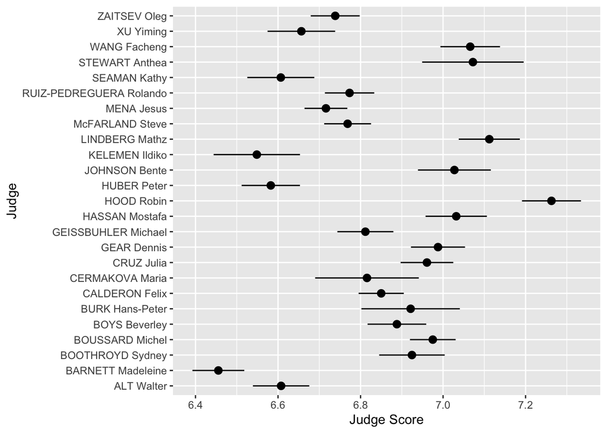

```r
judges <- judges + coord_flip()
judges
```

## Heat Maps and Plot Annotations

When both axes are quantitative, it can be useful to divide the plane into rectangular bins and summarize a third variable within each bin. The function `stat_summary_2d()` does that automatically.

Here, we divide the plot of average diver rank and average dive difficulty into rectangular bins and compute the mean judge score within each bin. The function `scale_fill_distiller()` lets us control the fill colors and legend title, and `annotate()` lets us draw reference shapes on top of the plot.

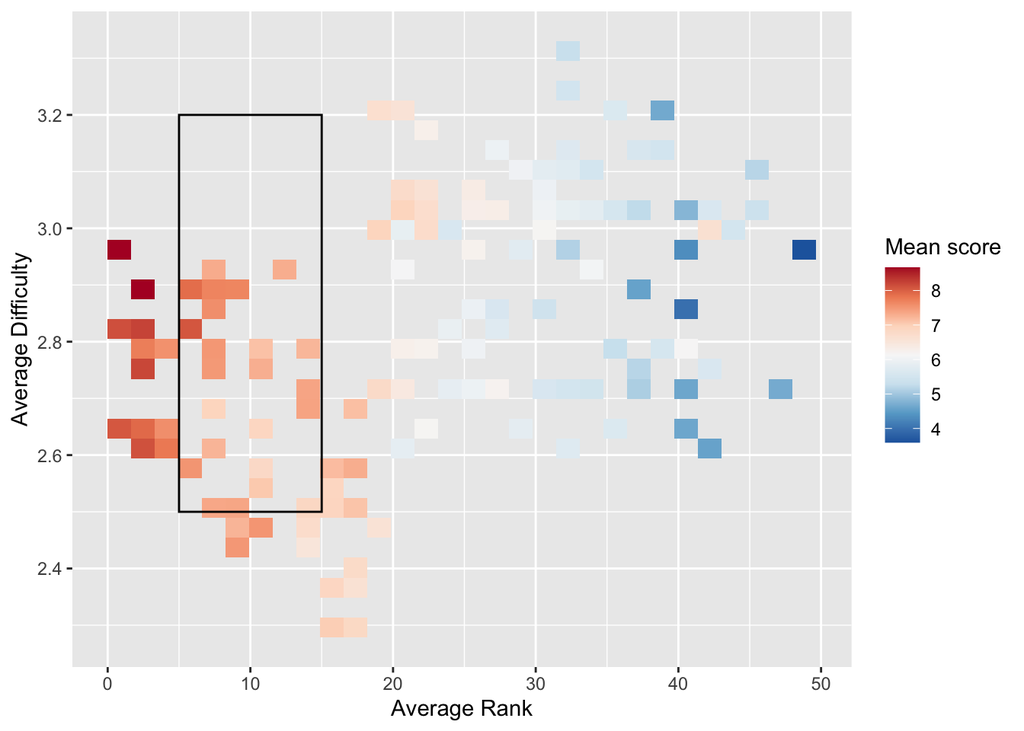

```r
ggplot(diving_grouped, aes(x = Rank_mean, y = Difficulty_mean, z = JScore_mean)) +
  stat_summary_2d() +
  scale_fill_distiller("Mean score", palette = "RdBu") +
  annotate("rect", xmin = 5, xmax = 15, ymin = 2.5, ymax = 3.2,
           alpha = 0, color = "black") +
  labs(x = "Average Rank", y = "Average Difficulty")
```

If your data are already summarized into a rectangular grid, `geom_tile()` is a direct way to build a heat map.

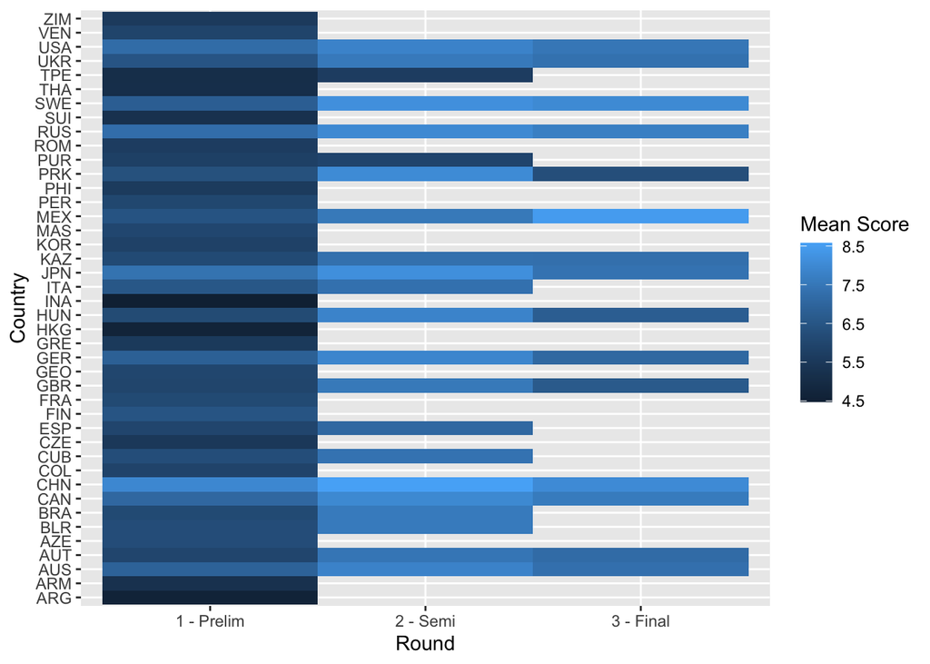

```r
diving_tile <- diving %>%
  group_by(Round, Country) %>%
  reframe(mean_score = mean(JScore))

ggplot(diving_tile, aes(x = Round, y = Country, fill = mean_score)) +
  geom_tile() +
  labs(x = "Round", y = "Country", fill = "Mean Score")
```

## Scales and 2D Histograms

We already used `scale_fill_distiller()` to control the fill colors in a heat map. We can also use scales to control point colors. We return to the scatter plot of the judges’ scores vs rank of the divers. This time, we want to color the points by the difficulty of the dive.

We use the layer `scale_color_distiller()`. The second word, `color`, is the `aes` we want to change. We can replace it with `x`, `y` or `fill`, depending on the `aes` we want to change.

The third word is `distiller`, which we use because our `color` variable, `Difficulty`, is continuous. If it were discrete, we would write `brewer` instead.

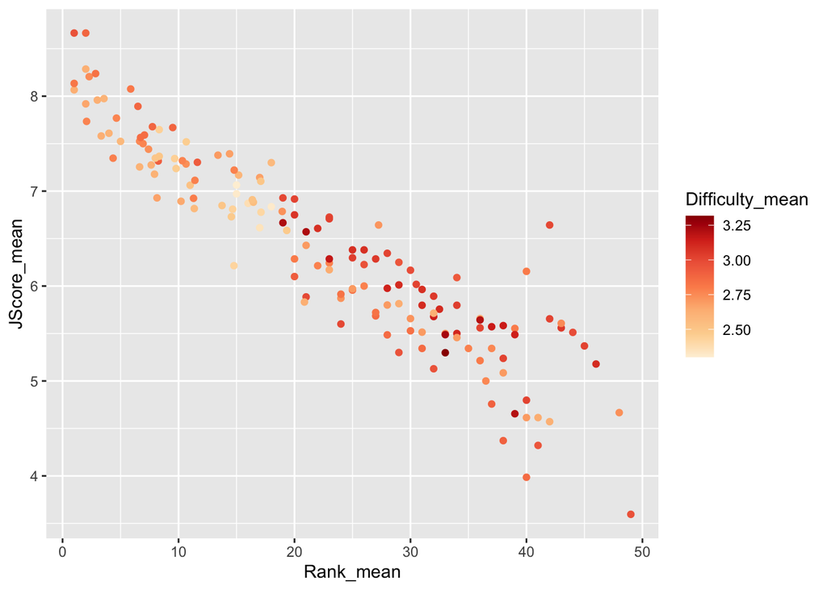

```r
scatter <- ggplot(data = diving_grouped) +
  geom_point(aes(x = Rank_mean, y = JScore_mean, color = Difficulty_mean)) +
  scale_color_distiller(palette = "OrRd", direction = 1)

scatter
```

Interestingly, it seems that some of the highest ranked divers perform most of the less difficult dives, but perform these easy dives very well.

To further investigate, we plot a 2D histogram of Rank vs Difficulty.

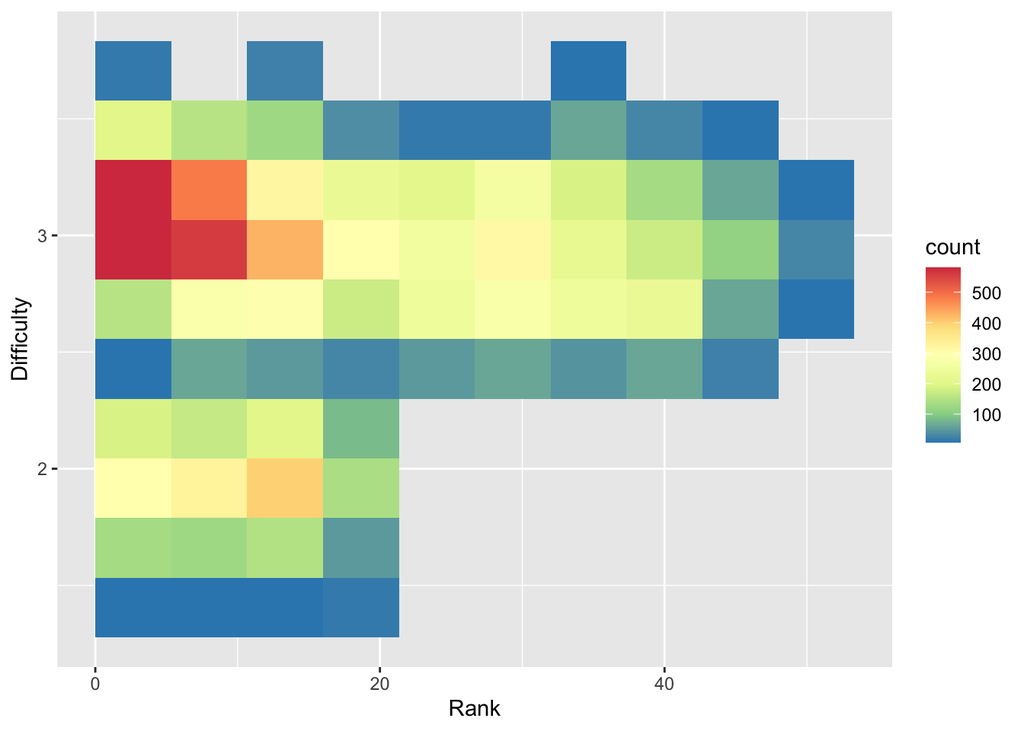

```r
hist <- ggplot(data = diving)  +
  geom_bin2d(aes(x = Rank, y = Difficulty), bins = 10) +
  scale_fill_distiller(palette = "Spectral")
hist
```

Note that we use `fill` instead of `color` in `scale_fill_distiller()` to control the fill of the histogram bins.

From the 2D histogram, we can see that the higher ranked divers attempt both more difficult and less difficult dives, unlike the lower ranked divers who only attempt more difficult dives.